# act_report

## Report: act_report

## Table des matières

- Introduction
- Analyse
- Visualisation
- Conclusion

### Introduction

Le présent rapport a pour objet de communiquer les observations et visualisations produites dans l’étape analyse et visualisation du projet **"Préparation et analyse de données"** . Les tableaux utilisés à cette étape sont ceux résultants du nettoyage à savoir `dogs_rating_clean` et `predictions`. `dogs_rating_clean` représente le *master data* et comporte les données d’archives améliorées, les données additionnelles collectées et les données sur les images utilisées pour les prédictions. Le tableau `predictions` comporte les données sur les prédictions successives des images associées à chaque tweet.

### Analyse

Mon analyse a été guidée par les questions suivantes:

- *Quelles sont les 10 races de chiens les plus prédites ?*
- *Quelles sont les 10 races de chiens les mieux notées ?*
- *Quelles sont les 10 races de chiens les plus appréciées ?*

#### Quelles sont les 10 races de chiens les plus prédites ?

Le but de cette question est d’identifier les races de chiens les plus récurrentes dans les prédictions successives, en particulier le classement du top 10. Pour chaque race appartenant à ce classement je veux connaître le rang, le nombre d’occurrences et la moyenne du degré de confiance avec lequel les images ont été prédites.

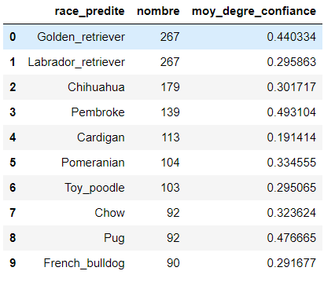

Liste du Top 10 des races de chiens les plus prédites

Le tableau qui précède montre que la race de chiens `Golden_retriever` est la plus récurrente dans les prédictions. Elle apparaît à *267* reprises avec une moyenne de degré de confiance moyen de *44%*, suivi de `Labrador_retriever`

#### Quelles sont les 10 races de chiens les mieux notées ?

Ici également le but est de faire un classement du top 10 des races de chiens les mieux notées. En revanche pour éviter que les résultats ne soient pas biaisés, en lieu et place de la moyenne des notes, j'ai plutôt opté pour la mesure que j'ai appelé `rating_ratio`, laquelle est le quotient du nombre d’occurrences sur les note médiane de chaque race. Avec cette mesure on obtient le classement qui suit:

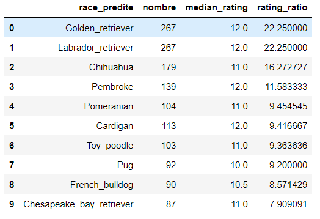

Liste du Top 10 des races de chiens ayant obtenue les meilleures notes

On peut observer que l'ordre du classement a été conservé, à quelques exceptions près. `Golden_retriever` et `Labrador_retriever` se partagent la tête de liste avec *12* comme notes médianes et *22,25* pour rating_ratio, suivi de `Chihuahua`. Les statistiques des notes ci-dessous, des races `Golden_retriever` et `Labrador_retriever` donnent un avantage à la première race qui reçoit une note moyenne (à effecif égal), *12,89* vs *12,36*

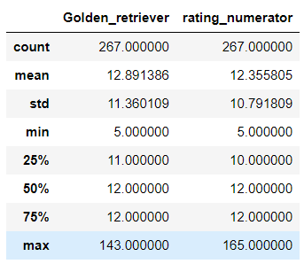

Statistiques des notes

#### Quelles sont les 10 races de chiens les plus appréciées ?

Ce classement utilise le nombre total de favoris comme mesure, en tenant compte de la tendance générale à avoir une préférence pour ce qu’on apprécie. Le résultat est présenté dans le tableau qui suit:

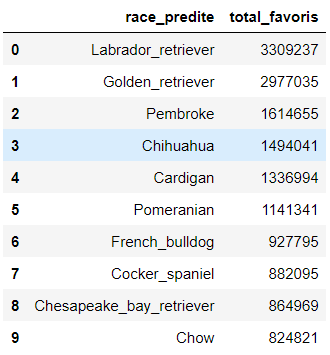

Liste du Top 10 des races de chiens ayant obtenue plus de favoris

Dans ce classement en revanche, on observe que `Labrador_retriever` qui occupait jusque-là la deuxième place passe en tête avec *3,3M* de favoris, suivi de `Golden_retriever` *~3M* de favoris. `Chesapeake_bay_retriever` n’apparaît pas dans Top 10 des races dont les prédictions ont été les plus récurrentes, mais occupe successivement la 10ème et la 9ème place dans le classement des races les mieux notées et celui des plus appréciées.

### Visualisation

Dans cette rubrique j'ai utilisé le graphique à barres pour illustrer le classement du Top 10 des races de chiens les mieux notées et celui des races les plus appréciées, respectivement. Celà permet de mieux apprécier les proportions dans chaque classement.

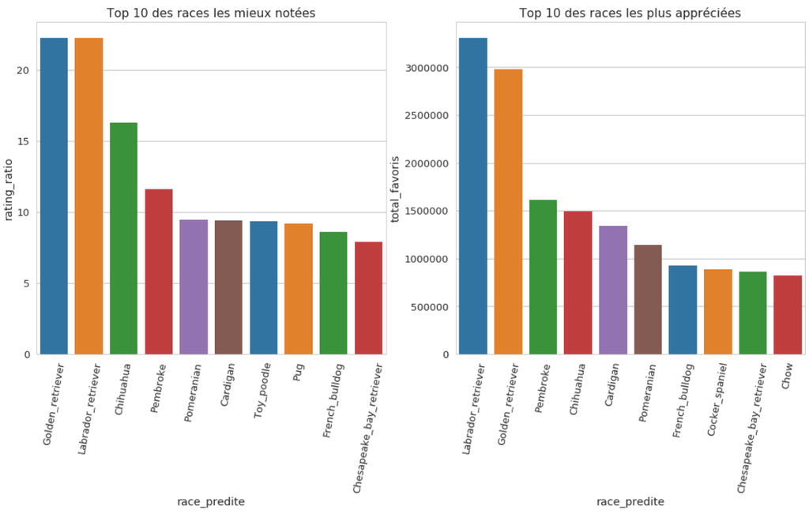

Top 10 des races de chiens les mieux notées et les plus appréciées

### Conclusion

Les observations faites dans notre analyse ainsi que la visualisation produite peuvent nous renseigner sur la tendance générale en matière de préférence de races de chiens chez les personnes et peuvent probablement orienter à l'adoption d'une race ou d'une autre de chiens.